```python
from IPython.display import display, SVG
import matplotlib.pyplot as plt
from matplotlib.ticker import PercentFormatter, EngFormatter, LogFormatter
import numpy as np
import pandas as pd
import seaborn as sns

%matplotlib inline
pd.options.display.float_format = '{:g}'.format
```

```python
plt.style.use('bmh')
plt.rcParams['figure.facecolor'] = 'silver'
plt.rcParams['figure.figsize'] = (16, 12)
plt.rcParams['patch.linewidth'] = 1
```

```python
ratings = pd.read_csv('./goodbooks-10k/ratings.csv')
books = pd.read_csv('./goodbooks-10k/books.csv')
```

The distribution of scores show that reviews are in general favourable.

```
4    2139018
5    1983093
3    1370916
2     359257
1     124195
Name: rating, dtype: int64
```

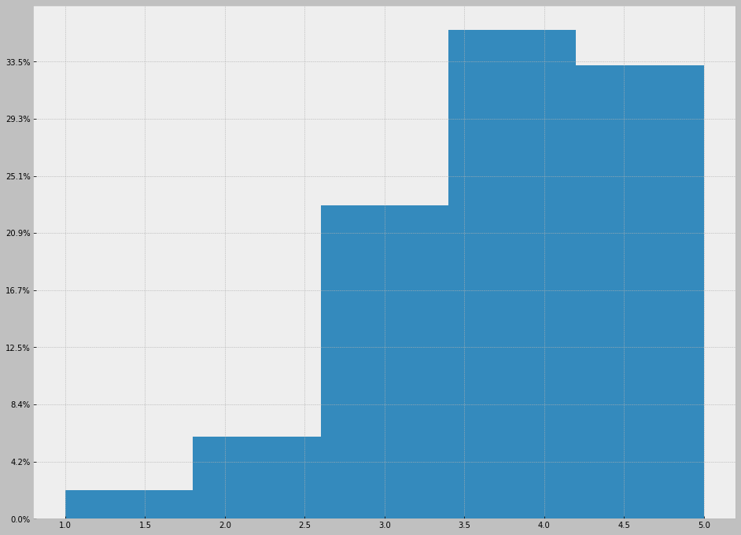

```python
ax = ratings.rating.hist(bins=5)
ax.yaxis.set_major_formatter(PercentFormatter(xmax=len(ratings)))
ratings.rating.value_counts()
```

The average scores given by users as well as the average scores received by a book are generally high. This may be because only good books draw attention to themselves and that they do so from the users who are likely to enjoy them. Certain users in particular seem to only give 5-star ratings.

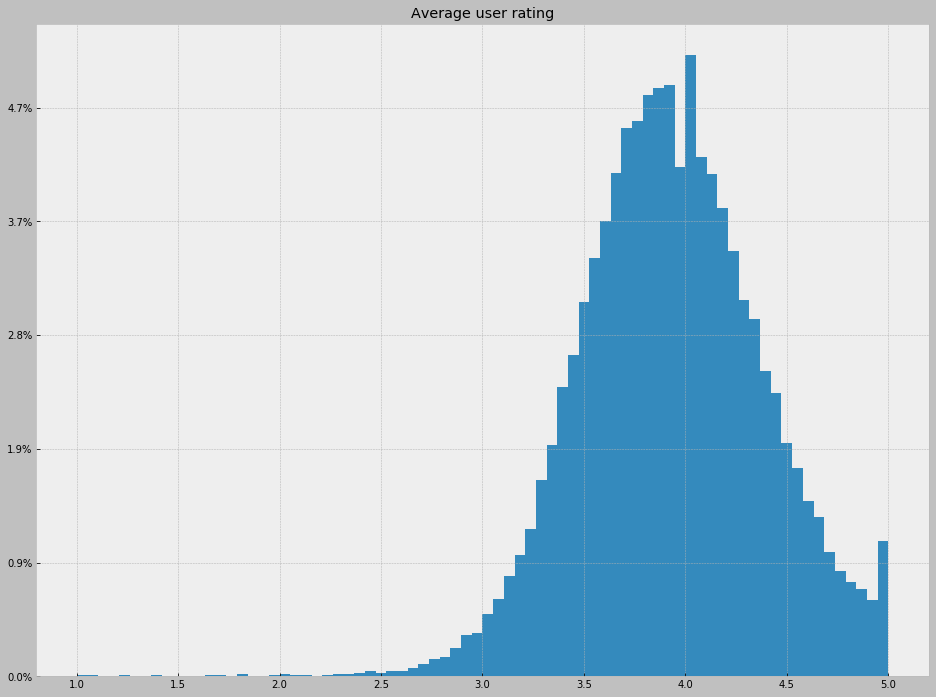

```python
ax = ratings.groupby('user_id').rating.apply(np.mean).hist(bins='rice')
ax.yaxis.set_major_formatter(PercentFormatter(xmax=ratings.user_id.max()))
ax.set_title('Average user rating');
```

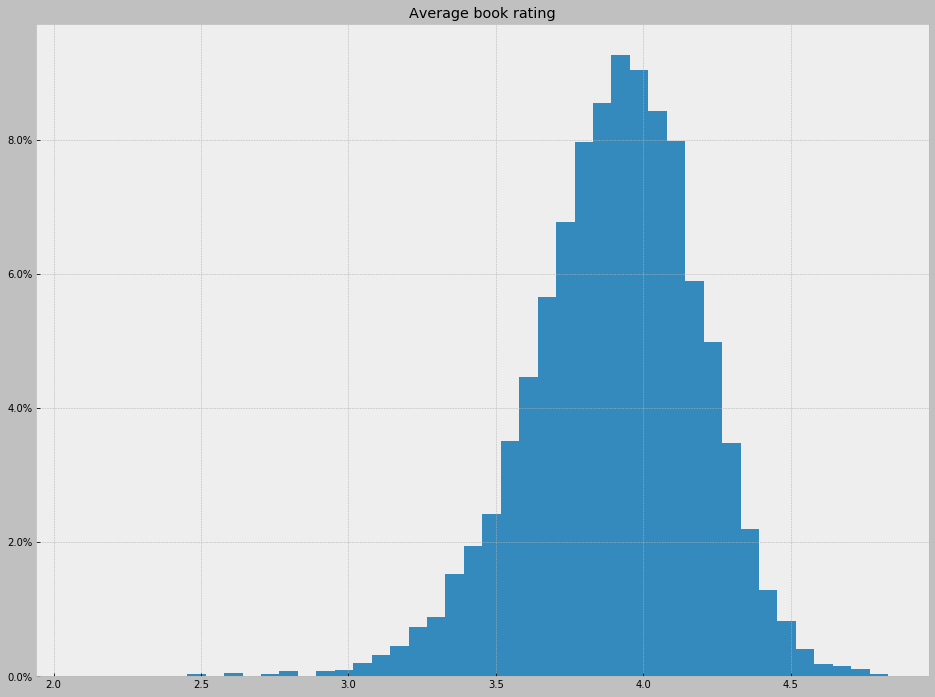

```python
ax = ratings.groupby('book_id').rating.apply(np.mean).hist(bins='rice')
ax.yaxis.set_major_formatter(PercentFormatter(xmax=ratings.book_id.max()))
ax.set_title('Average book rating');
```

The ammounts of reviews that books have seem to follow a Pareto distribution (a few books get almost all the reviews). The ammounts of reviews that users write describe a Gaussian distribution.

Books with almost no reviews appear to have been filtered out of the dataset as well as users with almost no reviews.

```
count     10000
mean    597.648
std     1267.29
min           8
25%         155
50%         248
75%         503
max       22806
Name: book_id, dtype: float64
```

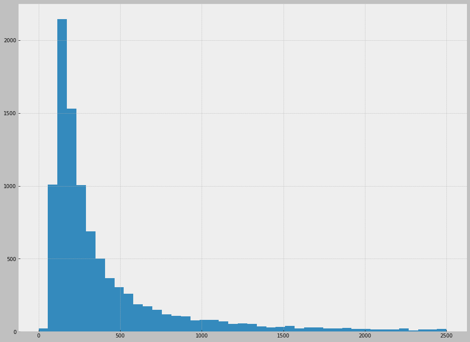

```python
reviews_per_book = ratings.groupby('book_id').book_id.apply(len)
reviews_per_book.hist(bins='rice', range=(0, 2500))
reviews_per_book.describe()
```

```
count     53424
mean    111.869
std     26.0712
min          19
25%          96
50%         111
75%         128
max         200
Name: book_id, dtype: float64
```

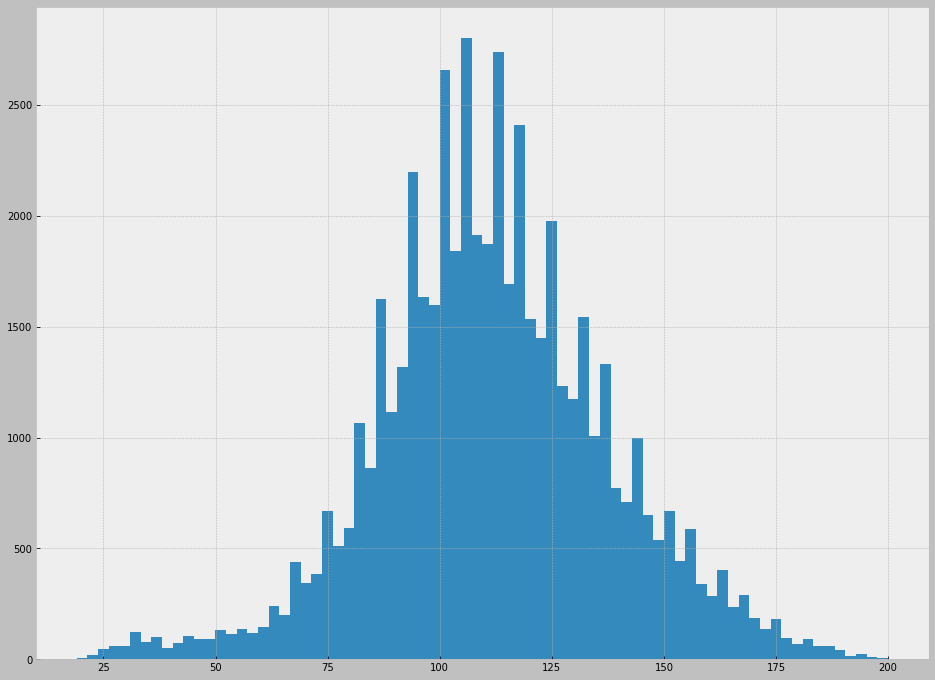

```python
reviews_per_user = ratings.groupby('user_id').book_id.apply(len)
reviews_per_user.hist(bins='rice')
reviews_per_user.describe()
```

When splitting the dataset in train/test-sets, users/books may be poorly represented in the resulting sets.

This is why, after performing a 75%-25% train/test split, I have computed the ratio of ratings for each book/user that have been selected in the training test and plotted them below.

The resulting distributions will be centered around 25% and should not contain too many extreme values (values close to 0% and 100%).

[figure not shown]

```python
test_ratings = ratings.sample(frac=.25, random_state=42)
train_ratings = ratings[~ratings.index.isin(test_ratings.index)]

fig, ax = plt.subplots(nrows=2, squeeze=True)

all_users = ratings.user_id.value_counts()
test_users = test_ratings.user_id.value_counts().reindex(index=all_users.index, fill_value=0)
users_ratio = test_users/all_users
ax[0].hist(users_ratio, bins='rice', label=str(users_ratio.describe()))
ax[0].set_title('User ratings test-set representation ratio')
ax[0].legend();

all_books = ratings.book_id.value_counts()
test_books = test_ratings.book_id.value_counts().reindex(index=all_books.index, fill_value=0)
books_ratio = test_books/all_books
ax[1].hist(books_ratio, bins='rice', label=str(books_ratio.describe()))
ax[1].set_title('Book ratings test-set representation ratio')
ax[1].legend();
```

This is where we define and train our neural network.

The InputLayer will receive pairs of values as input (which represent the user/book IDs) and will send each to their coresponding embeddings via the Lambda layers. These IDs will be used by the embeddings to select a row from their weights and them forward in the network.

The Multiply layer is supposed to identify the features of the book that the user will find appealing and the subsequent Dropout layer is there to mimick lack of knowledge (which our network should be robust against). The user/book biases are concatenated to this output. The reason why they don't go through tha Multiply-Dropout phase is because they are supposed to represent inherent qualities such as a book's popularity or a user's degree of criticism.

The resulting values are fed to a feed-forward neural network with the task of regressing over the ratings.

```python
import keras.backend as K
from keras.models import Model
from keras.layers import Dense, Embedding, Multiply, Input, Dropout, Lambda, Concatenate
from keras.utils.vis_utils import model_to_dot

def recommender(user_count, item_count, property_count):
    inp = Input(shape=(2, ), dtype='int32')

    u_select = Lambda(lambda x: x[:, 0] - 1, name='user_selector')(inp)
    u_emb = Embedding(user_count, property_count, name='users')(u_select)
    u_emb_bias = Embedding(user_count, 1, name='user_bias')(u_select)

    i_select = Lambda(lambda x: x[:, 1] - 1, name='item_selector')(inp)
    i_emb = Embedding(item_count, property_count, name='items')(i_select)
    i_emb_bias = Embedding(item_count, 1, name='item_bias')(i_select)

    tens = Multiply()([u_emb, i_emb])
    tens = Dropout(.5)(tens)
    tens = Concatenate()([tens, u_emb_bias, i_emb_bias])
    tens = Dense(15, activation='relu')(tens)
    tens = Dense(1)(tens)

    m = Model(inputs=inp, outputs=tens)
    m.compile(loss='mse', optimizer='adam', metrics=['mae'])
    return m
```

```python
rec = recommender(ratings.user_id.nunique(), ratings.book_id.nunique(), 15)
SVG(model_to_dot(rec).create(prog='dot', format='svg'))
```

[figure not shown]

```python
x_train, y_train = train_ratings[['user_id', 'book_id']], train_ratings.rating.values
x_test, y_test = test_ratings[['user_id', 'book_id']], test_ratings.rating.values

rec.fit(x_train, y_train, batch_size=1000, epochs=10, validation_data=(x_test, y_test),
        shuffle=True)
rec.save_weights('recommeder.hdf5')
```

```
Train on 4482359 samples, validate on 1494120 samples
```

```
<keras.callbacks.History at 0x1769ae7ef28>
```

```python
rec.load_weights('recommeder.hdf5')
```

Viewing the predictions in the test set (and then train set) grouped by the expected ratings.

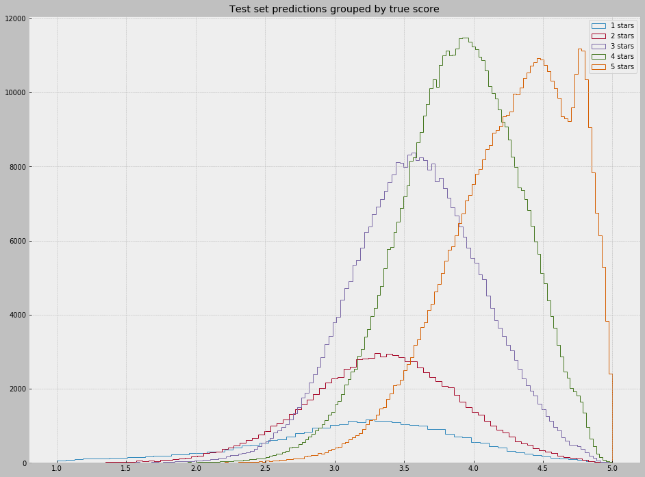

```python
preds = rec.predict(x_test)
for i in range(1, 6):
    plt.hist(preds[y_test == i], bins='rice', label=f'{i} stars', range=(1, 5), histtype='step')

plt.title('Test set predictions grouped by true score')
plt.legend()
```

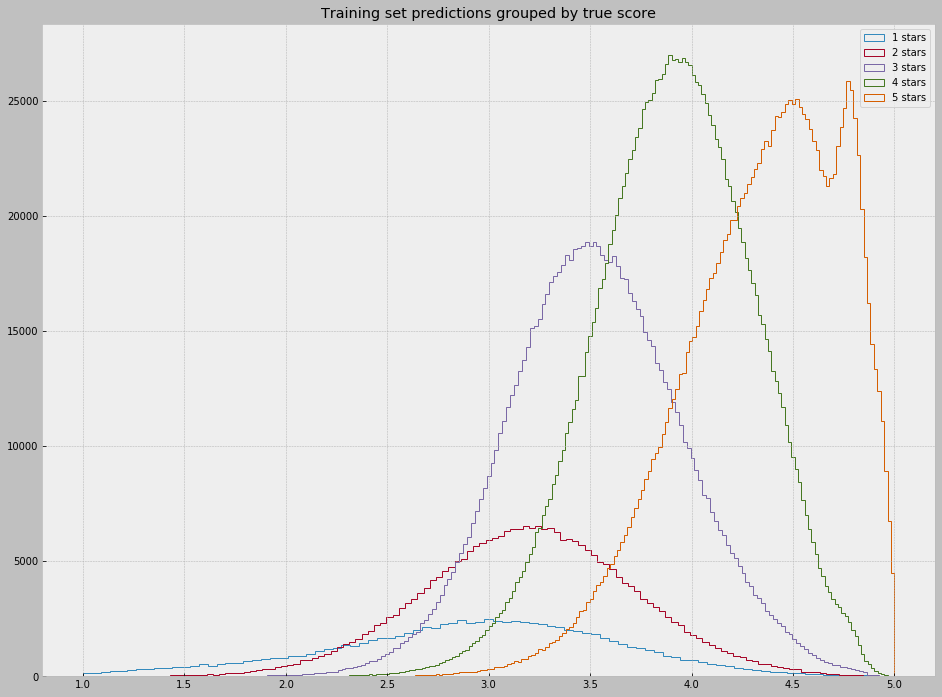

```python
preds = rec.predict(x_train)
for i in range(1, 6):
    plt.hist(preds[y_train == i], bins='rice', label=f'{i} stars', range=(1, 5), histtype='step')

plt.title('Training set predictions grouped by true score')
plt.legend()
```

Interpreting the embeddings obtained is difficult, because they are composed of many dimensions.

Principal Component Analysis is a technique that can be used to lower the dimensionality of data. It isolates the axes along which the data communicates the most information.

In our case, the first principal component (X-axis of the scatter plot) seems to encode whether a book is a difficult read or not. "Twilight" is located diametrically opposed to "The Catcher in Rye", "1984" and the "Great Gatsby". The "Harry Potter" series is clustered together and is close to the "Hunger Games" series, which is to be expected, because people are often fans of both series.

```python
from sklearn.decomposition import PCA
pca = PCA(n_components=2)
w = rec.get_layer('items').get_weights()[0]
book_pca = pca.fit(w.T).components_
```

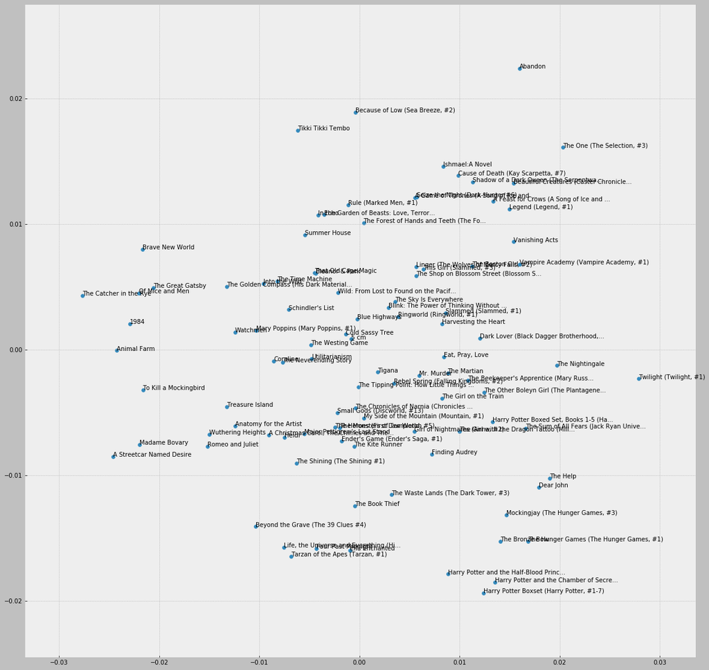

```python
idxs = books.sample(100, weights='ratings_count', random_state=42).id - 1
X = book_pca[0, idxs]
Y = book_pca[1, idxs]

def shorten(s):
    maxlen=40
    if len(s) > maxlen:
        return f'{s[:maxlen-3]}...'
    else:
        return s

plt.figure(figsize=(20, 20))
plt.scatter(X, Y)
for i, x, y in zip(idxs, X, Y):
    plt.text(x, y, shorten(books.iloc[i].title))
```